# Multiple Regression and Logistic Regression in R

Bhanji - Statistical Methods

2024-02-21

## Goals for today

Learn how to use linear regression with one continuous outcome and one or more predictors

- use scatterplots to check for non-linear associations
- understand model R<sup>2</sup>, F-statistic, beta coefficients (standardized, unstandardized)
- check model residuals for potential sources of bias
  - linearity, homoscedasticity, independence, normality and extreme cases
- F-statistic for model comparisons
- Examine curvilinear/quadratic associations (this wasn’t in the SPSS activity)
  - understand multi-collinearity and indicators (tolerance, VIF)
- Dichotomous outcome: logistic regression
  - why not use regular linear regression?
  - sigmoid link function (logit)
  - interpret coefficients as log-odds

## Step 1 - Get organized

- Now open RStudio and start a new project, select “Existing Directory” and select the folder you created for this activity
- **Earlier you downloaded lumos_subset1000plusimaginary.csv**
- In RStudio, start a new R markdown and do your work in there, save the file in a subfolder called r_docs
  - put these lines in your “setup” code chunk:  
    `knitr::opts_chunk$set(echo = TRUE)`  
    `knitr::opts_knit$set(root.dir = rprojroot::find_rstudio_root_file())`  
    `library(tidyverse)`
  - run the setup code chunk (the necessary `library()` statements are in there)
- In the RStudio console, install the packages you’ll need today with the install.packages() command:
  - `install.packages("GGally")`
  - `install.packages("parameters")`

## Step 2 - Import data and check it out

- data description: lumos_subset1000plusimaginary.csv is the same file we worked with last week. This is subset of a public dataset of lumosity (a cognitive training website) user performance data. You can find the publication associated with the full dataset here:  
  [Guerra-Carrillo, B., Katovich, K., & Bunge, S. A. (2017). Does higher education hone cognitive functioning and learning efficacy? Findings from a large and diverse sample. PloS one, 12(8), e0182276. https://doi.org/10.1371/journal.pone.0182276](https://doi.org/10.1371/journal.pone.0182276)
  - this data subset includes only the arithmetic reasoning test (AR) score from a post-test at the end of a 100 day training program (`raw_score`)
  - `pretest_score` (test at start of the training program) has been transformed to have a mean of 100 and standard deviation of 15 (this is a typical transformation for IQ scores)
- **What to do first:** Make a new code chunk and use readr::read_csv() to read in the data. Make sure that NA values are handled the way you want (click on the tibble in the Environment window pane to take a quick look).
- **What to do next:** make sure the columns that contain nominal vals are treated as nominal, using forcats::as_factor() *you can copy your code chunk from last week, or just look at the solution below*

```r
#first import the data
lumos_tib <- readr::read_csv("data/lumos_subset1000plusimaginary.csv", na = "NA")
# now make sure the columns we want as factors are treated that way, using forcats::as_factor()
lumos_tib <- lumos_tib %>% dplyr::mutate(
  test_type = forcats::as_factor(test_type),
  assessment = forcats::as_factor(assessment),
  gender = forcats::as_factor(gender),
  edu_cat = forcats::as_factor(edu_cat),
  english_nativelang = forcats::as_factor(english_nativelang),
  ethnicity = forcats::as_factor(ethnicity)
)
```

## Step 3 - The General Linear Model (GLM) with one predictor

**A note about terminology: (same as the note in the SPSS activity)** In this lab activity we will use the terms “predictor”, “independent variable (IV)”, and “explanatory variable” interchangeably to refer to variables that are entered as explanatory terms in the model. We will use the terms “dependent variable” and “outcome variable” interchangeably to refer to the variable that is being explained. You should be mindful of the implications of these words (e.g., about causality, which cannot be inferred simply by assigning one variable as a predictor and another as an outcome) but we won’t focus on language in this lab. Instead, you should get used to the different terminology that is used.

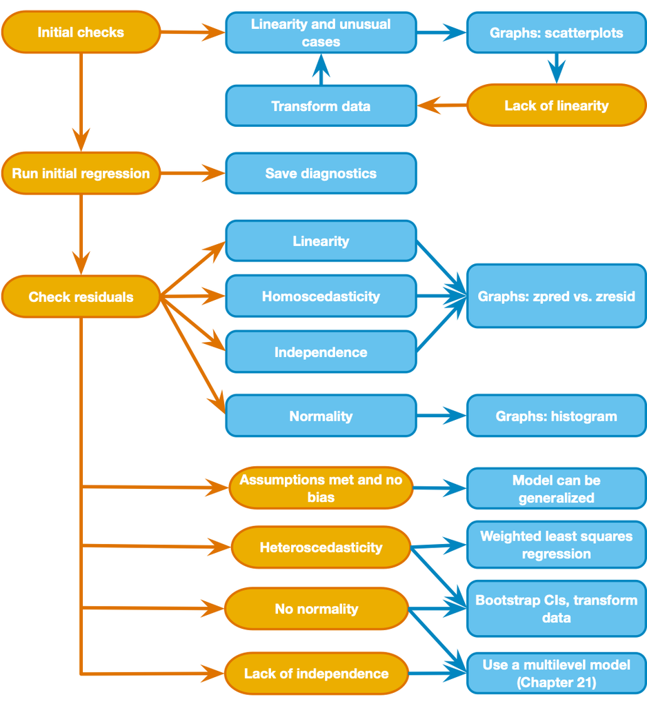

GLM Decision chart

#### Above is the decision process chart from the book.

- It says we should start by using scatter plots to check for non-linear associations and unusual cases.
- Last week we looked at scatter plots of pretest_score, raw_score, and age. The linearity assumption was reasonable and there were no concerning outliers, but let’s use a shortcut to recreate those scatter plots all at once. Use the function `GGally::ggscatmat()` like in the code below.

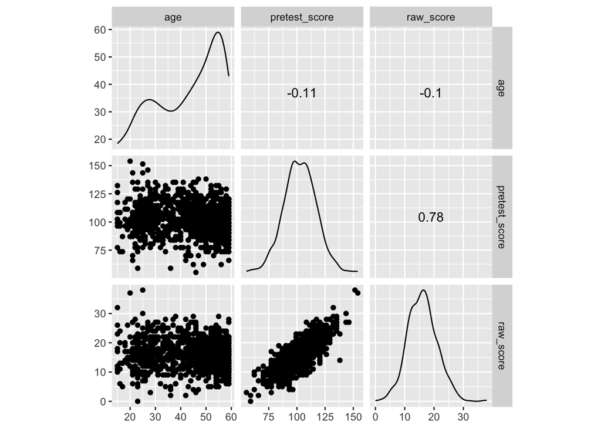

```r
p1 <- lumos_tib %>%
  GGally::ggscatmat(columns = c("age","pretest_score","raw_score"))
p1
```

- Notice that the `age` variable is not normally distributed, but normality of the variables, especially with a large data set is not a concern. The scatters show that a linear relation between variables is a reasonable assumption  
- So let’s dive straight in and use linear regression with `age` as an explanatory variable for `raw_score`  
- We will use the `lm()` function, piping in the data and specifying `age` as a predictor for `raw_score` with the argument `formula = raw_score ~ age` (an intercept term is automatically included). Save the model in a variable called `score_lm`  
- use `summary(score_lm)` to show the model summary

```r
score_lm <- lumos_tib %>% drop_na(age,raw_score) %>%
  lm(formula = raw_score ~ age)
summary(score_lm)
```

```
##
## Call:
## lm(formula = raw_score ~ age, data = .)
##
## Residuals:
##      Min       1Q   Median       3Q      Max
## -16.8899  -3.4962  -0.0183   3.1838  21.1927
##
## Coefficients:
##             Estimate Std. Error t value Pr(>|t|)
## (Intercept) 17.83974    0.58027   30.74  < 2e-16 ***
## age         -0.04130    0.01282   -3.22  0.00132 **
## ---
## Signif. codes:  0 '***' 0.001 '**' 0.01 '*' 0.05 '.' 0.1 ' ' 1
##
## Residual standard error: 5.003 on 998 degrees of freedom
## Multiple R-squared:  0.01028,    Adjusted R-squared:  0.009291
## F-statistic: 10.37 on 1 and 998 DF,  p-value: 0.001323
```

### Looking at the model summary:

1. The Multiple R-squared value tells us that `age` explains about 1.03% of the variance in `raw_score` (not much by most standards).
2. The F-statistic is the ratio of variance explained by the model to the error within the model (use `anova(score_lm)` to view Mean Sum of Squares for the model and residuals), and the p-value tells you the probability of an F-statistic at least that large under the null hypothesis.
3. The (unstandardized) beta coefficient (“Estimate” column, “age” row) tells you that a change of one unit in the predictor (age) predicts a change of -.04 units in the outcome (raw_score). In other words, the model predicts that two people one year apart in age will be .04 units apart in their performance score (the older person having the lower predicted score).
- you can get standardized coefficients by using the command `parameters::model_parameters(score_lm, standardize="refit")` (this function also gives you confidence intervals for parameters)- the standardized coefficient for `age` indicates that a change of +1 standard deviation in age predicts a change of -.10 standard deviations in `raw_score` it is the same as if we first standardized (z-scored) each variable and then ran the regression model.
4. The Intercept (“Estimate” column, “(Intercept)” row) tells us that if all predictors were at their zero level (i.e., at age zero) the model predicts a score of 17.84. It doesn’t make a lot of sense to talk about a score for someone age zero, but this is how linear models work. If you wanted an interpretable intercept you could re-scale `age` so that the zero value was meaningful (e.g., re-center to mean=0, then the intercept would correspond to the predicted score for someone with the mean age)
5. The “Std. Error” column gives the standard error of each estimate (intercept and age coefficient) – for a visual explanation of standard error of regression coefficients, see the [Andy Field video on the topic (same as the one in the syllabus)](https://youtu.be/3L9ZMdzJyyI).
6. The “t value” column gives the t-stat for each estimate (estimate/std err) and the “Pr(>|t|)” column gives the probability of observing a t-stat that far from zero under the null hypothesis.
- notice that the p-value for `age` (under “Pr(>|t|)”) is the same as the overall p-value - this is because age is the only predictor in the model
- notice that the t-stat and p-value for `age` are the same as the t-stat and p-value the we got last week for the correlation between `age` and `raw_score` - this is because the correlation is also a test of a linear relation (and `age` is the only predictor)

## Step 4 - The General Linear Model (GLM) with multiple predictors

Now let’s add `pretest_score` to our model, so that we are predicting `raw_score` as a function of `age` and `pretest_score`. See if you can write the code yourself (copy and edit the code from the previous step) before looking at the solution below. Store the model in a variable named `score_2pred_lm`.

```r
score_2pred_lm <- lumos_tib %>% drop_na(age,raw_score,pretest_score) %>%
  lm(formula = raw_score ~ age + pretest_score)
summary(score_2pred_lm)
```

```
##
## Call:
## lm(formula = raw_score ~ age + pretest_score, data = .)
##
## Residuals:
##      Min       1Q   Median       3Q      Max
## -11.7387  -2.0523   0.0005   2.1198   9.3891
##
## Coefficients:
##                 Estimate Std. Error t value Pr(>|t|)
## (Intercept)   -11.904994   0.846546 -14.063   <2e-16 ***
## age            -0.005794   0.008131  -0.713    0.476
## pretest_score   0.274721   0.007052  38.956   <2e-16 ***
## ---
## Signif. codes:  0 '***' 0.001 '**' 0.01 '*' 0.05 '.' 0.1 ' ' 1
##
## Residual standard error: 3.152 on 997 degrees of freedom
## Multiple R-squared:  0.6076, Adjusted R-squared:  0.6068
## F-statistic: 771.9 on 2 and 997 DF,  p-value: < 2.2e-16
```

#### Now, answer the following questions for yourself based on the model summary

1. What does the “Multiple R-squared” tell you for this model? That is, what percent of the variance in `raw_score` is explained by the model?
2. What does the overall F-statistic and p-value tell you?
3. What does the beta coefficient for `pretest_score` tell you?
4. What does it mean that the t-statistic for the `age` variable is not significant in this model? How does it compare to the partial correlation test that we ran last week with the same variables?

## Step 5 - Model diagnostics: Examine model residuals for potential sources of bias

Now, look back at the decision process chart. It says we should look at “zpred vs zresid” to check for linearity, heteroscedasticity, and independence, then look at a histogram of residuals to check for normality.

Fortunately, there is one easy function that will show everything we need: `plot(modelname)` - Use `plot(score_2pred_lm)` to show the diagnostic plots for the 2 predictor model from the last step.

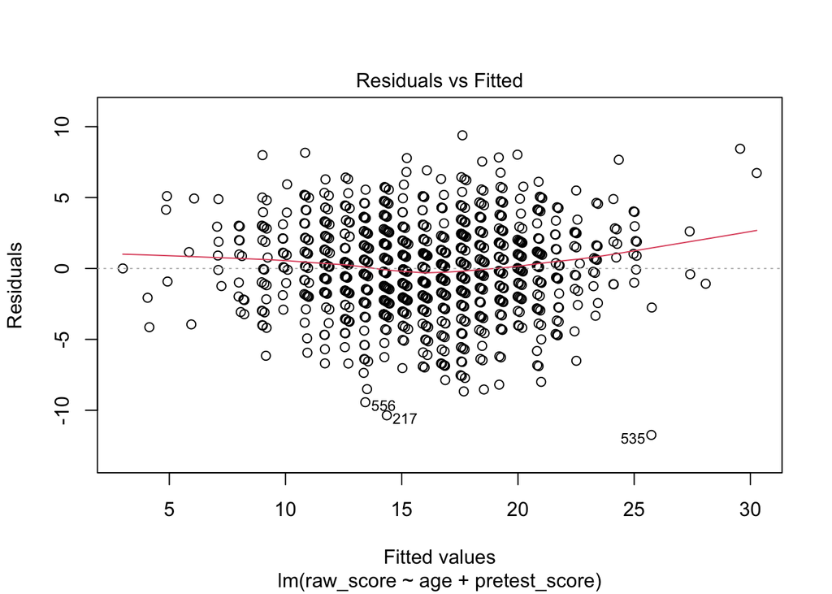

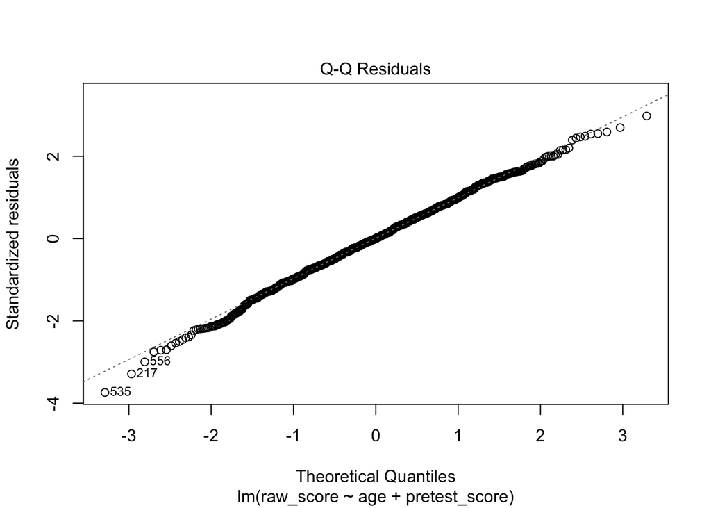

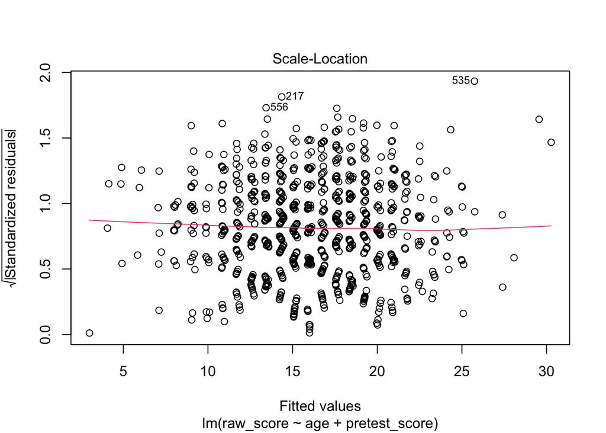

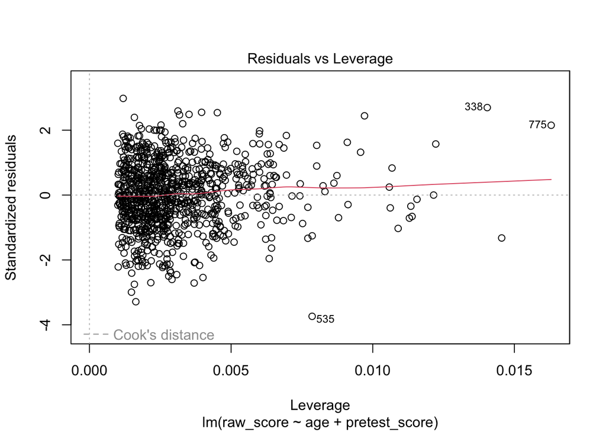

```r
plot(score_2pred_lm)
```

## Step 6 - Compare Models

We can compare two models (w/ the same outcome data) by computing an F-statistic based on the ratio of error (RSS=residual sum of squares) of one model to the other (for example, a full model with all predictors compared to less full model with a subset of predictors). If one model is better at explaining the outcome than the other, than the RSS of the worse model will be greater than the RSS of the better model, and the F-statistic quantifies that for us (and gives a p-value under the null hypothesis). You can also rephrase this F-statistic as a ratio based on R<sup>2</sup> for each model (see Chapter 9 of the Field Textbook, equation 9.18)  
- Let’s compare the last model (`age` and `pretest_score`) to the first model (`age` only) of `raw_score`. Because we are comparing the residual variance between models, we can use the `anova()` function in R. The arguments we pass are the names of the two models (put the fuller model second). Try it now.

```r
anova(score_lm, score_2pred_lm)
```

```
## Analysis of Variance Table
##
## Model 1: raw_score ~ age
## Model 2: raw_score ~ age + pretest_score
##   Res.Df     RSS Df Sum of Sq      F    Pr(>F)
## 1    998 24978.7
## 2    997  9903.8  1     15075 1517.6 < 2.2e-16 ***
## ---
## Signif. codes:  0 '***' 0.001 '**' 0.01 '*' 0.05 '.' 0.1 ' ' 1
```

- The p-value tells us that the F-stat is unlikely under the null hypothesis (that the models are equivalent). In other words, the difference in variance explained by `age`+`pretest_score` vs `age` alone is unlikely if the models equally explain variance in `raw_score` (so the fuller model is better.
- When you report a model comparison this way you report the F-statistic as well as the change in R-squared (R<sup>2</sup> of better model minus R<sup>2</sup> of the worse model). But one important issue is that adding more predictors will always increase R<sup>2</sup>.
- For this reason you may also report other indicators of model fit that account for the number of predictors, such as AIC and BIC (see Chapter 9 of the Field Textbook).
- You can view the AIC (Akaike Information Criterion) and BIC (Bayesian Information Criterion) for each model by using `broom::glance(modelname)` in R - lower AIC and BIC values indicate better model fit.

## Step 7 - Quadratic/curvilinear associations

When we looked just at `age` and `raw_score`, we saw a small association such that older participants scored lower. But is it possible that the association is really inverted U-shaped such that older is better at young ages, but worse at old ages? We can examine this possibility by including a quadratic (age<sup>2</sup>) term in the model. It’s as simple as centering the age variable (by subtracting the mean) and squaring it, then including that term in the model. It’s always best to include lower order terms when you add higher order terms, so our new formula will be `raw_score ~ age_ctr + age_squared` (first we have to compute `age_ctr` and `age_squared`). Try it now: first compute `age_ctr` and `age_squared`, then estimate the model with the new formula (store the model in a variable named `score_agesq_lm`).

```r
lumos_tib <- lumos_tib %>%
  mutate(
    age_ctr = age-mean(age),
    age_squared = age_ctr^2
  )
score_agesq_lm <- lumos_tib %>%  lm(formula = raw_score ~ age_ctr + age_squared)
summary(score_agesq_lm)
```

```
##
## Call:
## lm(formula = raw_score ~ age_ctr + age_squared, data = .)
##
## Residuals:
##      Min       1Q   Median       3Q      Max
## -16.5455  -3.4196  -0.0787   3.2473  21.3652
##
## Coefficients:
##              Estimate Std. Error t value Pr(>|t|)
## (Intercept) 16.448005   0.243438  67.566  < 2e-16 ***
## age_ctr     -0.059527   0.015266  -3.899 0.000103 ***
## age_squared -0.002668   0.001218  -2.191 0.028659 *
## ---
## Signif. codes:  0 '***' 0.001 '**' 0.01 '*' 0.05 '.' 0.1 ' ' 1
##
## Residual standard error: 4.993 on 997 degrees of freedom
## Multiple R-squared:  0.01503,    Adjusted R-squared:  0.01305
## F-statistic: 7.605 on 2 and 997 DF,  p-value: 0.0005273
```

#### Examine the model summary:

1. Notice that there are coefficient estimates for `age_ctr`, and `age_squared`.
2. The “Multiple R-squared” is .015 - we can compare that to the model that had age only (R-squared was .010), so the quadratic term increases the variance explained just a little bit. The p-value for `age_squared` tells us that it is unlikely (p=.029) to find a t-stat this large under the null hypothesis (that the age_squared association is zero).
3. You can go through the rest of the summary like before, but now let’s spare a moment to think about **multi-collinearity**.

#### Multi-collinearity (textbook Chapter 9, section 9.9.3)

- when predictors in the model are highly correlated with each other, we have *multi-collinearity* and the estimates of coefficients for correlated terms are unstable (large std err and highly variable across samples)
- an easy way to check for multi-collinearity is by computing the *VIF* (variance inflation factor) for each predictor. It measures the shared variance between one predictor and the others. The reciprocal of VIF is called *tolerance*. A general rule of thumb is that you should worry if you have VIF > 5 for any predictor in the model.
- check the VIF for each predictor now, by running `car::vif(score_agesq_lm)` – looks okay, right? But what if we hadn’t centered the age variable before squaring it?

## Step 8 - Dichotomous outcome: logistic regression

Logistic regression is used when the outcome variable has just two possible values (e.g., true/false, on/off, yes/no, or greater/less than some critical threshold). For the sake of learning, let’s imagine that a `raw_score` value of 16 or greater wins a $100 prize, so we want to see if we can predict who wins the prize based only on their years of education (`years_edu`).  
**Why can’t we run a regular linear regression?** - Because regular linear regression will give you predicted values that fall outside the possible outcome values and are not interpretable.  
Logistic regression will yield predicted values between 0 and 1 that can be interpreted as the probability of the outcome (e.g., prize received) occurring. These predicted values follow a sigmoid-shaped logit function.

#### Let’s estimate a logistic model now

- First create a new variable called `prize` that is 1 if `raw_score` is >= 16. Peek at the solution code to see how.
- Now use the `glm()` function (glm=generalized linear model) to estimate the logistic model. Just like with `lm()` you can specify the formula as `prize ~ years_edu`, but now add the argument `family=binomial` to specify that you are estimating a logistic model.
- store the model in a variable called `prize_binlm`, and use `summary(prize_binlm)` to view the model summary, and `anova(prize_binlm, test="LRT")` for the likelihood ratio test (labeled “Chi-square” in SPSS)
- use the last three lines of code to first store all the predicted probabilities from the model (`predicted_probs <- fitted(prize_binlm)`), and then use them to make a classification table like the one you saw in SPSS (`table(...)`)

```r
lumos_tib <- lumos_tib %>%
  mutate(prize = ifelse(raw_score>=16,1,0)) #if raw_score>=16 set prize to 1 (else 0)
prize_binlm <- lumos_tib %>% drop_na(prize,years_edu) %>%
  glm(formula = prize ~ years_edu, family = binomial)

# for the classification table:
cat("Classification Table:\n")
predicted_probs <- fitted(prize_binlm)
table((lumos_tib %>% drop_na(prize, years_edu))$prize, predicted_probs>.5,
      dnn = c("observed","predicted"))

#for the coefficients table:
summary(prize_binlm)
#for the overall chi-square test
anova(prize_binlm, test = "LRT")
```

```
## Classification Table:
##         predicted
## observed FALSE TRUE
##        0   165  207
##        1   110  313
##
## Call:
## glm(formula = prize ~ years_edu, family = binomial, data = .)
##
## Coefficients:
##             Estimate Std. Error z value Pr(>|z|)
## (Intercept) -2.22288    0.44192  -5.030 4.91e-07 ***
## years_edu    0.15099    0.02802   5.388 7.14e-08 ***
## ---
## Signif. codes:  0 '***' 0.001 '**' 0.01 '*' 0.05 '.' 0.1 ' ' 1
##
## (Dispersion parameter for binomial family taken to be 1)
##
##     Null deviance: 1098.8  on 794  degrees of freedom
## Residual deviance: 1068.4  on 793  degrees of freedom
## AIC: 1072.4
##
## Number of Fisher Scoring iterations: 4
##
## Analysis of Deviance Table
##
## Model: binomial, link: logit
##
## Response: prize
##
## Terms added sequentially (first to last)
##
##
##           Df Deviance Resid. Df Resid. Dev  Pr(>Chi)
## NULL                        794     1098.8
## years_edu  1   30.431       793     1068.4 3.459e-08 ***
## ---
## Signif. codes:  0 '***' 0.001 '**' 0.01 '*' 0.05 '.' 0.1 ' ' 1
```

#### Interpretation:

-First look at the Classification Table - The table shows how many cases the model (including `years_edu`) predicted to have a `prize` value of 1 (meaning the predicted probability from the logit function was > .5), and this is split up according to whether the actual/observed value was 1. So the overall accuracy is (165+313)/795 = 60.13%

- Now, notice there is no R<sup>2</sup> value. This is because there is no universally agreed method for computing it, but you can compute something similar to what SPSS provides if you want (e.g., see documentation for the [DescTools Package](https://www.rdocumentation.org/packages/DescTools/versions/0.99.41/topics/PseudoR2))
- The “Analysis of Deviance Table” includes the Chi-square test of model fit (same as the test in the “Model Summary” in SPSS. The chi-square stat is in the “Deviance” column. This test is based on the log-likelhood of the model. From the Field textbook, “log-likelihood is based on summing the probabilities associated with the predicted, P(Yi), and actual, Yi, outcomes. It is analogous to the residual sum of squares in the sense that it is an indicator of how much unexplained information there is after the model has been fitted.” (p. 1378, section 20.3.2). The log-likelihood is used to compute a deviance statistic that has a Chi-square distribution, and we use the Chi-square distribution to compute the probability of obtaining a statistic that large under the null hypothesis to get our overall model significance (p-value).
- Let’s focus on the coefficient estimate for `years_edu` (in the table called “Coefficients” in the model summary. In logistic regression, the coefficients are in units of log(odds) (log = natural logarithm). This means that if we increase a value of `years_edu` by one unit the model would predict an increase of .151 in the log(odds) of receiving a prize. We can try to make that more understandable by converting the coefficient to an odds ratio by *exponentiating* it (raising *e* to the power of the coefficient - see section 20.3.5 of the Field textbook). If you exponentiate our coefficient of .151 (in your R code you could add `exp(prize_binlm$coefficients)`) you would get *e*<sup>0.151</sup> = 1.16, meaning that a 1 year increase in `years_edu` would predict a ~16% increase in odds of receiving the prize (according to the model). A number below 1 would mean that higher `years_edu` was related to lower odds of receiving the prize.
  - the z stat for each term is based on the coefficient divided by its standard error, and it is the square root of the Wald z<sup>2</sup> stat that we got in our SPSS output for the same model. So the Sig. value tells us the probability of a coefficient this large under the null hypothesis. The Field textbook advises that we interpret this probability with caution because the p-value can be inaccurate for large coefficients. Significance of individual predictors is best done by using the likelihood ratio test (Chi-square) to compare a model with versus without each predictor. In SPSS you can do this by entering each predictor in a separate Block, then the **Model Summary** will give you tests that compare models between each Block. So the Sig. value tells us the probability of a coefficient this large under the null hypothesis. The Field textbook advises that we interpret this probability with caution because the p-value can be inaccurate for large coefficients. Significance of individual predictors is best done by using the likelihood ratio test (`anova(prize_binlm, test = "LRT")`) to compare a model with versus without each predictor. For a model with a single predictor you can just use the overall Chi-square test. For models with multiple predictors you would run one model with out your predictor of interest, one model with the predictor, and use the `anova()` function to compare the models.
- We can plot the model predictions with a few lines of code using `ggplot` (the y-axis is the predicted probability of `prize`) as in this code (the `stat_smooth()` function computes the logistic curve):

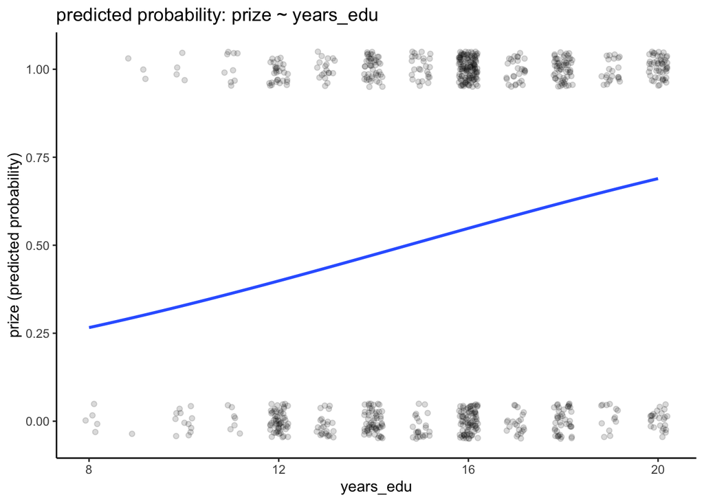

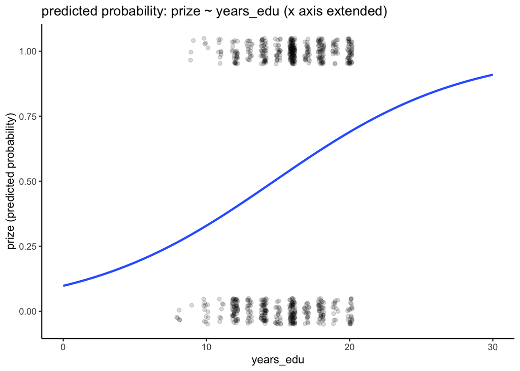

```r
p8a <- lumos_tib %>% drop_na(prize,years_edu) %>%
  ggplot(aes(x=years_edu, y=prize)) +
    geom_point(alpha=.15, position = position_jitter(w = 0.2, h = .05)) +
    stat_smooth(method="glm", se=FALSE, method.args = list(family=binomial),
                fullrange = TRUE) +
    labs(title = "predicted probability: prize ~ years_edu",
         y= "prize (predicted probability)") +
    theme_classic()

# or extend the x-scale to see the full shape of the logistic curve (according to the model, you would need ~30 years of education to give yourself a 90% shot at the prize!! but the max years_edu value is 20 in this data)
p8b <- lumos_tib %>% drop_na(prize,years_edu) %>%
  ggplot(aes(x=years_edu, y=prize)) +
    geom_point(alpha=.15, position = position_jitter(w = 0.2, h = .05)) +
    scale_x_continuous(limits = c(0,30)) +
    stat_smooth(method="glm", se=FALSE, method.args = list(family=binomial),
                fullrange = TRUE) +
    labs(title = "predicted probability: prize ~ years_edu (x axis extended)",
         y= "prize (predicted probability)") +
    theme_classic()
p8a; p8b
```

- We didn’t check the same sources of bias (non-linearity, heteroscedasticity, lack of independence) that we did for the linear regression example. Rather than linearity bewteen predictor and outcome, logistic regression assumes that the relation of predictors to log(odds) of the outcome is linear. Homoscedasticity/Homogeneity of variance is not an assumption of logistic regression. We do need to assume independence, because non-independent measures (e.g., unmodeled groups or repeated measures) cause a problem called *overdispersion*. Refer to the Field textbook (Chapter 20) for a complete overview of logistic regression and how to check assumptions. [This resource at STHDA is also useful](http://www.sthda.com/english/articles/36-classification-methods-essentials/148-logistic-regression-assumptions-and-diagnostics-in-r/#logistic-regression-diagnostics)

#### That’s all for this activity!

## References

- Chapters 9, 20 of textbook
- Field, A.P. (2021). Discovering Statistics Using R and RStudio. Second. London: Sage.